# Adoption Data

Layla Parast

Note that I added a table of contents compared to the class version. toc_float puts it to the side, play around with removing it.

If you have some packages you want to load, you can do them here (instead of doing it further down right before we plot something.)

You can hide it like this (won’t show).

# **1. Dataset Information**

The **shelter.csv** dataset contains variables collected from adult cats and dogs that were adopted at the Austin Animal shelter over the course of one month.

First, you’ll want to import in the dataset (note that the default working directory is the folder in which this .Rmd file is located):

Let’s get a summary of the variables:

```
##        ID        Intake.Type          Species              Sex
##  Min.   :  1.0   Length:119         Length:119         Length:119
##  1st Qu.: 30.5   Class :character   Class :character   Class :character
##  Median : 60.0   Mode  :character   Mode  :character   Mode  :character
##  Mean   : 60.0
##  3rd Qu.: 89.5
##  Max.   :119.0
##    Age.Intake      Condition         Intake.Weight    Adopted.Weight
##  Min.   : 2.000   Length:119         Min.   : 0.300   Min.   : 0.30
##  1st Qu.: 2.000   Class :character   1st Qu.: 2.875   1st Qu.: 3.65
##  Median : 3.000   Mode  :character   Median : 9.000   Median : 9.50
##  Mean   : 4.059                      Mean   :15.649   Mean   :15.93
##  3rd Qu.: 5.000                      3rd Qu.:15.900   3rd Qu.:16.00
##  Max.   :15.000                      Max.   :71.500   Max.   :71.60
##  Days.to.Adoption
##  Min.   : 4.00
##  1st Qu.:23.50
##  Median :35.00
##  Mean   :37.71
##  3rd Qu.:50.50
##  Max.   :86.00
```

## **Cases**

Let’s look at a few rows of the dataset:

```
##   ID     Intake.Type Species    Sex Age.Intake Condition Intake.Weight
## 1  1           Stray     Dog Female         10      Sick          3.30
## 2  2           Stray     Dog   Male          3   Injured         54.00
## 3  3           Stray     Dog Female          6    Normal          9.50
## 4  4 Owner Surrender     Cat Female         15    Normal          9.80
## 5  5           Stray     Dog Female          3    Normal         48.25
## 6  6 Owner Surrender     Cat Female          2    Normal         10.50
##   Adopted.Weight Days.to.Adoption
## 1            4.8               86
## 2           55.0               37
## 3            9.6               24
## 4            9.9               79
## 5           48.4               49
## 6           10.5               28
```

# **2. Making Tables**

You can create a table manually like the example below, which describes the variables in this dataset:

| Variable | Description |
| --- | --- |
| ID | Unique identifier |
| Intake.Type | How animal arrived at the shelter |
| Species | Dog or cat |
| Sex | Female or male |
| Age.Intake | Age (years) at intake |
| Condition | Animal’s health condition |
| Intake.Weight | Weight (lbs) at intake |
| Adopted.Weight | Weight (lbs) at adoption |
| Days.to.Adoption | Days spent in the shelter |

# **3. Code and Output**

Code is run linearly (dependent on what is run above):

```
## [1] 37.70588
```

You can suppress the code:

```
## [1] 37.70588
```

You can also suppress the output:

# **4. Graphs and Embedding Code**

[Note that here I added the standard deviation and rounded to 2 decimal places.]

[Also note that this is called “inline” R code - you will be asked to do it in your homework.]

On average, animals spent 37.7058824 days with a standard deviation of 19.11 before being adopted.

Code not hidden:

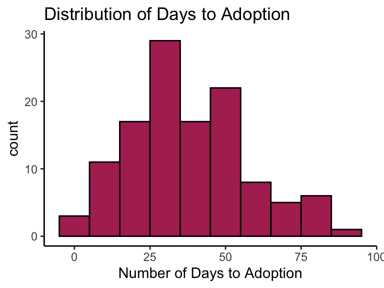

Code hidden and only plotting histogram:

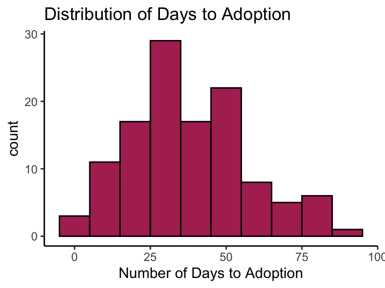

Make some text stand out like this:

> *This has been a great day!*

You can write some math equations like this:

Let $\alpha\ = 5$ and $\beta\ = 14$.

# **5 Class Exercises, Part 2**

Pick another variable from this dataset and investigate if the number of days to adoption is related to it or not. I will pick the variable Condition which is equal to Normal, Injured, or Sick. The code below pulls from code used in class on August 29 and August 31.

```
##   Condition Days.to.Adoption
## 1   Injured         51.10526
## 2    Normal         31.16883
## 3      Sick         48.52174
```

Dogs and cats that are not sick or injured seem to be adopted more quickly. The average days to adoption for Normal animals is 31.1688312, the average days to adoption for Injured animals is 51.1052632, and the average days to adoption for Sick animals is 48.5217391.

Here is another way to do it:

```
##
## Injured  Normal    Sick
##      19      77      23
```

| Animal Condition | My Count |
| --- | --- |
| Injured | 19 |
| Normal | 77 |
| Sick | 23 |

The average days to adoption for Normal animals is 31.1688312, the average days to adoption for Injured animals is 51.1052632, and the average days to adoption for Sick animals is 48.5217391.

Now let’s make a plot. This is one numeric and one categorical variable.

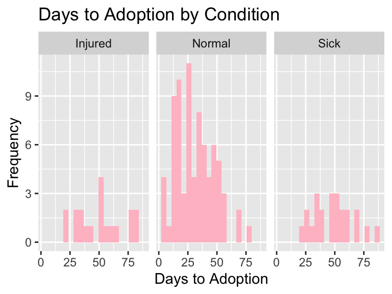

Present your statistics in a bulleted list. Note that spacing and tabs in the text below is VERY important. If you don’t have a space between * and The, it won’t work. If the spacing is off for the +, it won’t work.

- The average days to adoption by condition is:
  - 31.17 for Normal animals
  - 51.11 for Injured animals
  - 48.52 for Sick animals

Include a hyperlink that takes you to the Austin Animal Shelter’s website.

Go [here](https://www.austintexas.gov/austin-animal-center) to learn more!

Include a picture of a cute cat or dog. You must have the file of the photo you are using *in your working directory*.

```
##
## Injured  Normal    Sick
##      19      77      23
```

| Condition | Count |
| --- | --- |
| Injured | 19 |
| Normal | 77 |
| Sick | 23 |

Look at this cute dog:

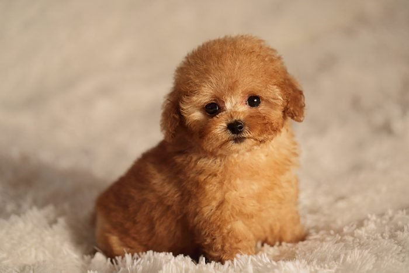